# Piramides de población con ggplot2

Las pirámides de población son de los gráficos más comunes en el análisis demográfico, y es probable que los que realizan trabajos o investigaciones en las ciencia sociales terminen creando algunos de cuando en vez. Como no existe una geometría en `ggplot2` para hacer este tipo de visualizaciones, podría ser un tanto difícil hacerlas.

En esta publicación haremos pirámides de población usando ggplot2. Mostraremos la distribución porcentual de la población por grupos quinquenales de edad y luego por edad específica. Finalemente terminaremos con una animación en la que se presenta la evolución de la composición demográfica del país según las estimaciones y proyecciones oficiales de población. El código y la data para reproducir todo el contenido lo pueden encontrar en el repositorio en [github de la publiación](https://github.com/Johan-rosa/poramides_de_poblacion).

## Paquetes

```r
library(tidyverse)
library(gganimate)
```

## La data

El set de datos lo publicó la Oficina Nacional de Estadísticas, auque, por la forma en la que comparten la información, hubo antes que reestructurar los resultados (El excel con los archivos originales está en la ruta [“data/proyeccion_poblacion_edad.xlsx”](https://github.com/Johan-rosa/poramides_de_poblacion/blob/master/data/proyeccion_poblacion_edad.xlsx) del repositorio, por otro lado, la manipulación realizada está en el script [“scripts/data_wrangling.R”](https://github.com/Johan-rosa/poramides_de_poblacion/blob/master/scripts/data_wrangling.R)). La reestructuración consistió en combinar los datos para hombres y mujeres, y separar en columnans distintas la edad simple y en grupos quinquenales.

```r
poblacion <- readRDS("data/poblacion.RDS")
head(poblacion)
```

| edad | edad_quinquenal | year | poblacion | sexo | total | porcentaje_total |
| --- | --- | --- | --- | --- | --- | --- |
| 0 | 0-4 | 2000 | 102282 | Hombres | 8397802 | 1.217962 |
| 1 | 0-4 | 2000 | 101945 | Hombres | 8397802 | 1.213949 |
| 2 | 0-4 | 2000 | 102298 | Hombres | 8397802 | 1.218152 |
| 3 | 0-4 | 2000 | 102526 | Hombres | 8397802 | 1.220867 |
| 4 | 0-4 | 2000 | 102585 | Hombres | 8397802 | 1.221570 |
| 5 | 5-9 | 2000 | 102524 | Hombres | 8397802 | 1.220843 |

## A crear pirámides de población

El primer paso para crear las pirámides es hacer negativos los valores de uno de los dos sexos, así es posible que los resultados de cada uno se deplieguen en direcciones opuestas en el gráfico. En este ejemplo la cantidad o porcentaje de hombres según edad estará en negativo.

```r
poblacion_piramide <- poblacion %>%
  mutate(
    porcentaje_total = ifelse(sexo == "Hombres", -porcentaje_total, porcentaje_total),
    poblacion = ifelse(sexo == "Hombres", -poblacion, poblacion)
    )
```

### Pirámide para un año con `geom_col()`

La geometría `geom_col()` es quizás la más común para la creación de este tipo de gráficos. En este primer caso la estrategia es mapear `edad_quinquenal` al eje X y `porcentaje_total` al eje Y.

La estructura de la data podría conducir a la realización de pasos innecesarios, porque como la desagregación de los datos es a nivel de edades simples, cualquiera podría pensar que debe sumar la población de las edades simples en cada grupo quinquenal, pero en realidad para tener barras con las edades en grupos quinquenales solo hay que apilar las barras de las edades simples. La función la función `geom_col()` tiene dististas posiciones, el argumento `position = "stack` ayuda en este sentido. De igual forma, se coloca comentado el paso que intuitivamente se hubiese tenido que dar.

El eje del gráfico es el próximo elemento a configurar, porque el porcentaje de hombres está en negativo y no sería adecuado dejar las etiquetas del eje así, porque no tendría sentido. La solución sería utilizar función `scale_y_continuous(labels = abs)`, en esta el argumento `labels` puede recibir una función para transformar las etiquetas que por defecto genera ggplot, en este caso la del valor absoluto.

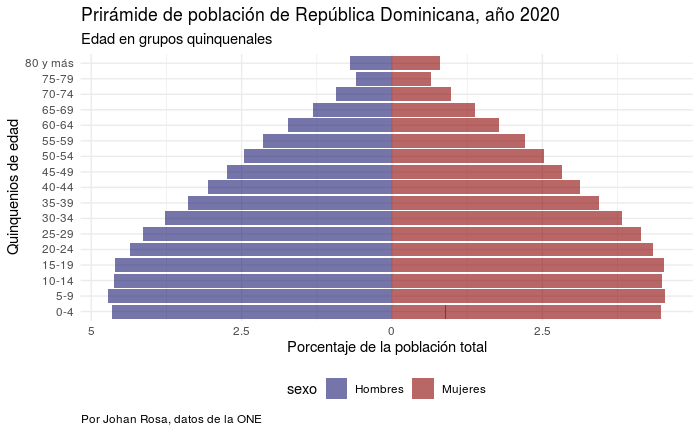

```r
subset(poblacion_piramide, year == 2020) %>%
  # group_by(edad_quinquenal, sexo) %>%
  # summarise(
  #   poblacion = sum(poblacion),
  #   porcentaje_total = sum(porcentaje_total)
  #   ) %>%
  ggplot(aes(x = edad_quinquenal, y = porcentaje_total, fill = sexo)) +
  # agregar el argumento color = "white", si gustan
    geom_col(position = "stack", alpha = 0.6) +
    coord_flip() +
  # colores que me gustan
    scale_fill_manual(values = c("midnightblue", "darkred")) +
  # thema minimalista
    theme_minimal() +
  # leyenda para el fondo
    theme(legend.position = "bottom", plot.caption = element_text(hjust = 0)) +
  # etiquetas en positivo
    scale_y_continuous(labels = abs) +
    labs(
      y = "Porcentaje de la población total",
      x = "Quinquenios de edad",
      title = "Prirámide de población de República Dominicana, año 2020",
      subtitle = "Edad en grupos quinquenales",
      caption = "Por Johan Rosa, datos de la ONE")

ggsave("visualizaciones/piramide_2020.png")
```

Ahora una secuencia de gráficos para visualizar cómo ha cambiado la estructura de la población en cada década y qué se espera para el año 2030. Aquí lo más evidente es la reducción de la base de la pirámide, con cada vez menos personas en edades inferiores a 15 años, también hay más ancianos.

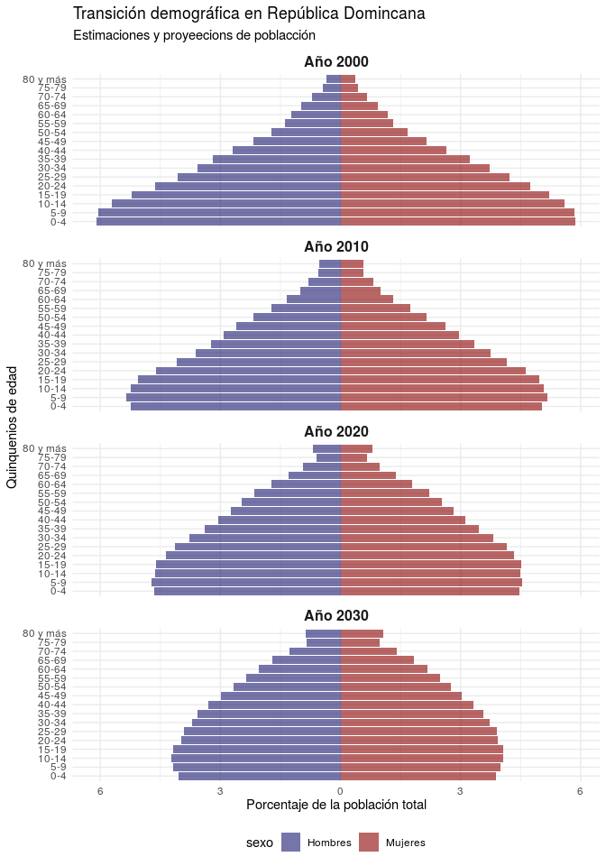

```r
poblacion_piramide %>%
  filter(str_detect(year, "[0]$")) %>%
  ggplot(aes(x = edad_quinquenal, y = porcentaje_total, fill = sexo)) +
  geom_col(alpha = 0.6) +
  scale_fill_manual(values = c("midnightblue", "darkred")) +
  facet_wrap(~paste("Año", year), ncol = 1) +
  coord_flip() +
  theme_minimal() +
  theme(legend.position = "bottom",
        strip.text = element_text(size = 12, face = "bold")
        ) +
  scale_y_continuous(labels = abs) +
  labs(
    y = "Porcentaje de la población total",
    x = "Quinquenios de edad",
    title = "Transición demográfica en República Domincana",
    subtitle = "Estimaciones y proyeecions de poblacción")
```

```r
ggsave("visualizaciones/priramides_00_10_20_30.png")
```

## Pirámides de población con `geom_area()`

Para pirámides de población con las edades simples la recomendación una geometría más suave, que de la apariencia de ser continua. `geom_area()` cumple esta función. En este ejemplo se excluyen las edades superiores a 79 años, por no estar desagregadas en grupos quinquenales y distorcionar un poco la cuspide de la pirámide.

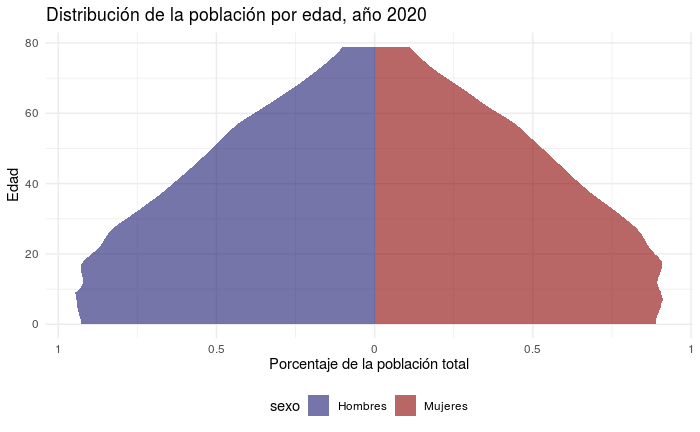

```r
 poblacion_piramide %>%
  filter(year == 2020, edad < 80) %>%
  ggplot(aes(
    x = edad, y = porcentaje_total,
    fill = sexo)
    ) +
  geom_area(alpha = 0.6) +
  coord_flip() +
  theme_minimal() +
  scale_y_continuous(labels = abs) +
  scale_fill_manual(values = c("midnightblue", "darkred")) +
  theme(legend.position = "bottom") +
  #transition_time(year) +
  labs(
    title = 'Distribución de la población por edad, año 2020',
    x = "Edad",
    y ='Porcentaje de la población total')

ggsave("visualizaciones/poblacion_edad_simple_2020.png")
```

### Ahora una animación

Como elemento final una animación de la transición demográfica, para esta animación se utilizan funciones de `{ggplot2}` y `{gganimate}`. No es la primera vez que se publican animaciones en este espacio, hacerlas no tiene mayores complicaciones. En el caso de las pirámides de población simplemente se agrega la variable que guiará la tansición `transition_time(year)` y se compila el resultado.

Estoy terminando una publiación específica para animaciones, que mostrará las diferentes cosas que se pueden crear con el paquete gganimate de [Thomas Lin Pedersen](https://github.com/thomasp85), los detalles sobre este tema se quedarán para esa publicación.

Una cosas más, para crear los archivos gif de las animaciones hay que tener instalados dos paquetes`{transformr}` y `{gifski}`.

```r
p <- poblacion_piramide %>%
 filter(edad < 80) %>%
  ggplot(aes(
    x = edad, ymin = base,
    ymax = porcentaje_total,
    fill = sexo)
    ) +
  geom_ribbon(alpha = 0.5) +
  coord_flip() +
  theme_minimal() +
  scale_y_continuous(labels = abs) +
  scale_fill_manual(values = c("midnightblue", "darkred")) +
  theme(legend.position = "bottom") +
  transition_time(year) +
  labs(
    title = 'Distribución de la población por edad, año: {as.integer(frame_time)}',
    x = "Edad",
    y ='Porcentaje de la población total')

animate(p, nframes = 60, renderer = gifski_renderer("visualizaciones/piramide_animation.gif"))
```

[output not shown]

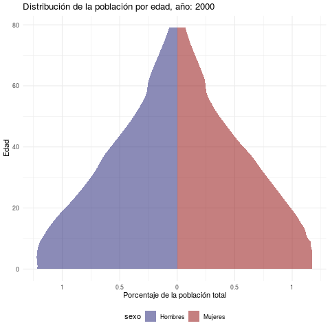

Por el momento eso es todo, suerte haciendo sus propias pirámides.